# 1_2_LIB_Pandas_Basic01_IRIS_V12_2610

> 🛠️ **2026.10 수정본 (V12)** — 원본: `1_2_LIB_Pandas_Basic01_IRIS_V11_2411.ipynb`
> - 윈도우 전용 폰트 경로(`C:/Windows/Fonts/...`) 대신 `koreanize-matplotlib`로 한글 폰트를 잡도록 바꿨어요. 이제 코랩·윈도우·맥 어디서나 같은 셀로 한글이 보여요. (Python 3.12부터 빠진 `distutils` 때문에 생기는 오류를 막으려고 `setuptools`도 함께 설치해요.)

## Pandas 라이브러리 기본 알아보기

- 데이터 처리와 분석을 위한 파이썬 라이브러리
- R의 data.frame과 유사하게 설계한 DataFrame이라는 데이터 기반으로 만들어짐.
- 데이터 분석시에 속도도 빠르고 많은 기능을 가지고 있어, 머신러닝 데이터 분석을 수행시에 많이 사용됨.
- 데이터를 읽고, 쓰기가 비교적 용이함.

### 주요 기능

- 데이터 로딩 및 저장
- 결측값 처리
- 데이터 필터링 및 선택
- 그룹화 및 집계
- 시계열 데이터 처리
- 데이터 정렬 및 재구성
- 참조 url : https://pandas.pydata.org/

### 학습 내용

- 대표적인 데이터 셋 Iris의 기본 데이터 탐색
- 행열 확인, 데이터 앞뒤 확인, 데이터 요약값 확인 등
- 행열 선택

### 판다스의 2가지 자료형

- Series(시리즈) 자료형
- DataFrame(데이터 프레임) 자료형

### 01 판다스 불러오기

```python
import pandas as pd
```

### 02 데이터 준비

```python
import seaborn as sns
```

```python
iris = sns.load_dataset("iris")
iris
```

|  | sepal_length | sepal_width | petal_length | petal_width | species |
| --- | --- | --- | --- | --- | --- |
| 0 | 5.1 | 3.5 | 1.4 | 0.2 | setosa |
| 1 | 4.9 | 3.0 | 1.4 | 0.2 | setosa |
| 2 | 4.7 | 3.2 | 1.3 | 0.2 | setosa |
| 3 | 4.6 | 3.1 | 1.5 | 0.2 | setosa |
| 4 | 5.0 | 3.6 | 1.4 | 0.2 | setosa |
| ... | ... | ... | ... | ... | ... |
| 145 | 6.7 | 3.0 | 5.2 | 2.3 | virginica |
| 146 | 6.3 | 2.5 | 5.0 | 1.9 | virginica |
| 147 | 6.5 | 3.0 | 5.2 | 2.0 | virginica |
| 148 | 6.2 | 3.4 | 5.4 | 2.3 | virginica |
| 149 | 5.9 | 3.0 | 5.1 | 1.8 | virginica |

150 rows × 5 columns

```python
### seaborn에서 불러온 데이터 셋은 판다스 데이터 프레임이 된다.
type(  iris  )
```

```
pandas.DataFrame
```

```python
### 데이터 프레임의 데이터의 각 열은 시리즈이다.
type(  iris['species']  )
```

```
pandas.Series
```

### 03. Pandas 기본

- 데이터 살펴보자.

```python
### 행, 열 확인
iris.shape
```

```
(150, 5)
```

```python
### 컬럼명 확인
iris.columns
```

```
Index(['sepal_length', 'sepal_width', 'petal_length', 'petal_width',
       'species'],
      dtype='str')
```

```python
### 앞의 데이터 살펴보기 - 기본값은 5, 숫자 지정시 해당 행이 보임
iris.head()
```

|  | sepal_length | sepal_width | petal_length | petal_width | species |
| --- | --- | --- | --- | --- | --- |
| 0 | 5.1 | 3.5 | 1.4 | 0.2 | setosa |
| 1 | 4.9 | 3.0 | 1.4 | 0.2 | setosa |
| 2 | 4.7 | 3.2 | 1.3 | 0.2 | setosa |
| 3 | 4.6 | 3.1 | 1.5 | 0.2 | setosa |
| 4 | 5.0 | 3.6 | 1.4 | 0.2 | setosa |

```python
### 뒤의 데이터 살펴보기 - 기본값은 5, 숫자 지정시 해당 행이 보임
iris.tail()
```

|  | sepal_length | sepal_width | petal_length | petal_width | species |
| --- | --- | --- | --- | --- | --- |
| 145 | 6.7 | 3.0 | 5.2 | 2.3 | virginica |
| 146 | 6.3 | 2.5 | 5.0 | 1.9 | virginica |
| 147 | 6.5 | 3.0 | 5.2 | 2.0 | virginica |
| 148 | 6.2 | 3.4 | 5.4 | 2.3 | virginica |
| 149 | 5.9 | 3.0 | 5.1 | 1.8 | virginica |

### 데이터 행수 개수를 지정해서 보기

```python
print(  iris.head(7)  )
print()
print(  iris.tail(7)  )
```

```
   sepal_length  sepal_width  petal_length  petal_width species
0           5.1          3.5           1.4          0.2  setosa
1           4.9          3.0           1.4          0.2  setosa
2           4.7          3.2           1.3          0.2  setosa
3           4.6          3.1           1.5          0.2  setosa
4           5.0          3.6           1.4          0.2  setosa
5           5.4          3.9           1.7          0.4  setosa
6           4.6          3.4           1.4          0.3  setosa

     sepal_length  sepal_width  petal_length  petal_width    species
143           6.8          3.2           5.9          2.3  virginica
144           6.7          3.3           5.7          2.5  virginica
145           6.7          3.0           5.2          2.3  virginica
146           6.3          2.5           5.0          1.9  virginica
147           6.5          3.0           5.2          2.0  virginica
148           6.2          3.4           5.4          2.3  virginica
149           5.9          3.0           5.1          1.8  virginica
```

```python
# 데이터 정보를 전체적으로 확인해 보기
iris.info()
```

```
<class 'pandas.DataFrame'>
RangeIndex: 150 entries, 0 to 149
Data columns (total 5 columns):
 #   Column        Non-Null Count  Dtype
---  ------        --------------  -----
 0   sepal_length  150 non-null    float64
 1   sepal_width   150 non-null    float64
 2   petal_length  150 non-null    float64
 3   petal_width   150 non-null    float64
 4   species       150 non-null    str
dtypes: float64(4), str(1)
memory usage: 6.0 KB
```

```python
# 데이터 수치형에 대해 알아보기
iris.describe()
```

|  | sepal_length | sepal_width | petal_length | petal_width |
| --- | --- | --- | --- | --- |
| count | 150.000000 | 150.000000 | 150.000000 | 150.000000 |
| mean | 5.843333 | 3.057333 | 3.758000 | 1.199333 |
| std | 0.828066 | 0.435866 | 1.765298 | 0.762238 |
| min | 4.300000 | 2.000000 | 1.000000 | 0.100000 |
| 25% | 5.100000 | 2.800000 | 1.600000 | 0.300000 |
| 50% | 5.800000 | 3.000000 | 4.350000 | 1.300000 |
| 75% | 6.400000 | 3.300000 | 5.100000 | 1.800000 |
| max | 7.900000 | 4.400000 | 6.900000 | 2.500000 |

```python
# 데이터 범주형에 대한 정보 확인
iris.describe(include=['O'])
```

|  | species |
| --- | --- |
| count | 150 |
| unique | 3 |
| top | setosa |
| freq | 50 |

```python
# 데이터에 비어 있는지 알아보기 (결측치 확인)
iris.isnull().sum()
```

```
sepal_length    0
sepal_width     0
petal_length    0
petal_width     0
species         0
dtype: int64
```

### 행 선택

```python
print( iris )

iris.iloc[ 0:10 , : ]  # 맨 앞에서 10행 선택
```

```
     sepal_length  sepal_width  petal_length  petal_width    species
0             5.1          3.5           1.4          0.2     setosa
1             4.9          3.0           1.4          0.2     setosa
2             4.7          3.2           1.3          0.2     setosa
3             4.6          3.1           1.5          0.2     setosa
4             5.0          3.6           1.4          0.2     setosa
..            ...          ...           ...          ...        ...
145           6.7          3.0           5.2          2.3  virginica
146           6.3          2.5           5.0          1.9  virginica
147           6.5          3.0           5.2          2.0  virginica
148           6.2          3.4           5.4          2.3  virginica
149           5.9          3.0           5.1          1.8  virginica

[150 rows x 5 columns]
```

|  | sepal_length | sepal_width | petal_length | petal_width | species |
| --- | --- | --- | --- | --- | --- |
| 0 | 5.1 | 3.5 | 1.4 | 0.2 | setosa |
| 1 | 4.9 | 3.0 | 1.4 | 0.2 | setosa |
| 2 | 4.7 | 3.2 | 1.3 | 0.2 | setosa |
| 3 | 4.6 | 3.1 | 1.5 | 0.2 | setosa |
| 4 | 5.0 | 3.6 | 1.4 | 0.2 | setosa |
| 5 | 5.4 | 3.9 | 1.7 | 0.4 | setosa |
| 6 | 4.6 | 3.4 | 1.4 | 0.3 | setosa |
| 7 | 5.0 | 3.4 | 1.5 | 0.2 | setosa |
| 8 | 4.4 | 2.9 | 1.4 | 0.2 | setosa |
| 9 | 4.9 | 3.1 | 1.5 | 0.1 | setosa |

### 열 선택

```python
print( iris.columns )

iris.iloc[ : , 0:1 ] # 맨 첫번째 열 선택
```

```
Index(['sepal_length', 'sepal_width', 'petal_length', 'petal_width',
       'species'],
      dtype='str')
```

|  | sepal_length |
| --- | --- |
| 0 | 5.1 |
| 1 | 4.9 |
| 2 | 4.7 |
| 3 | 4.6 |
| 4 | 5.0 |
| ... | ... |
| 145 | 6.7 |
| 146 | 6.3 |
| 147 | 6.5 |
| 148 | 6.2 |
| 149 | 5.9 |

150 rows × 1 columns

```python
iris.loc[ 0:5 ,  : ] # 행 인덱스 0~5 선택
```

|  | sepal_length | sepal_width | petal_length | petal_width | species |
| --- | --- | --- | --- | --- | --- |
| 0 | 5.1 | 3.5 | 1.4 | 0.2 | setosa |
| 1 | 4.9 | 3.0 | 1.4 | 0.2 | setosa |
| 2 | 4.7 | 3.2 | 1.3 | 0.2 | setosa |
| 3 | 4.6 | 3.1 | 1.5 | 0.2 | setosa |
| 4 | 5.0 | 3.6 | 1.4 | 0.2 | setosa |
| 5 | 5.4 | 3.9 | 1.7 | 0.4 | setosa |

```python
iris.loc[ : ,  'sepal_length':'petal_width' ] # 첫번째 컬럼부터 네번째 컬럼 선택
```

|  | sepal_length | sepal_width | petal_length | petal_width |
| --- | --- | --- | --- | --- |
| 0 | 5.1 | 3.5 | 1.4 | 0.2 |
| 1 | 4.9 | 3.0 | 1.4 | 0.2 |
| 2 | 4.7 | 3.2 | 1.3 | 0.2 |
| 3 | 4.6 | 3.1 | 1.5 | 0.2 |
| 4 | 5.0 | 3.6 | 1.4 | 0.2 |
| ... | ... | ... | ... | ... |
| 145 | 6.7 | 3.0 | 5.2 | 2.3 |
| 146 | 6.3 | 2.5 | 5.0 | 1.9 |
| 147 | 6.5 | 3.0 | 5.2 | 2.0 |
| 148 | 6.2 | 3.4 | 5.4 | 2.3 |
| 149 | 5.9 | 3.0 | 5.1 | 1.8 |

150 rows × 4 columns

- last update : 24/11, @by DJ, Lim

### 실습해 보기

- 1. 위의 내용을 타이타닉 데이터 셋에 대해 수행해 보기
  - 추가 목표:
    - 1. 1등석(First Class)에 탑승한 승객만 추출
    - 2. 생존한 여성 승객만 추출
    - 3. 나이가 30세 미만이고 생존한 승객 추출
    - 4. 성별과 생존 여부에 따른 승객 수 교차표 만들기
    - 5. 추출한 데이터의 요약 통계 출력하기
- 2. 위의 내용을 와인 데이터 셋에 대해 수행해 보기
  - https://archive.ics.uci.edu/ml/machine-learning-databases/wine-quality/winequality-red.csv
  - https://archive.ics.uci.edu/ml/machine-learning-databases/wine-quality/winequality-white.csv
  - A. 레드와인과 화이트와인 데이터셋의 불러와서 이를 병합시켜보자.
  - B. 와인 품질별 평균 알코올 함량과 와인 수

### 와인 품질 데이터 셋

```python
import matplotlib.pyplot as plt
import matplotlib.font_manager as fm

# 한글 폰트 설정 (코랩·윈도우·맥 공통)  # 2026.10 수정: 윈도우 폰트 경로(C:/Windows/Fonts) 하드코딩 → koreanize-matplotlib로 교체
%pip install -q koreanize-matplotlib setuptools
import setuptools  # 2026.10 수정: Python 3.12+엔 distutils가 없어 koreanize-matplotlib가 실패 → setuptools가 대신 제공
import koreanize_matplotlib  # 나눔고딕을 matplotlib 기본 폰트로 등록
plt.rcParams['axes.unicode_minus'] = False  # 마이너스 기호 깨짐 방지
```

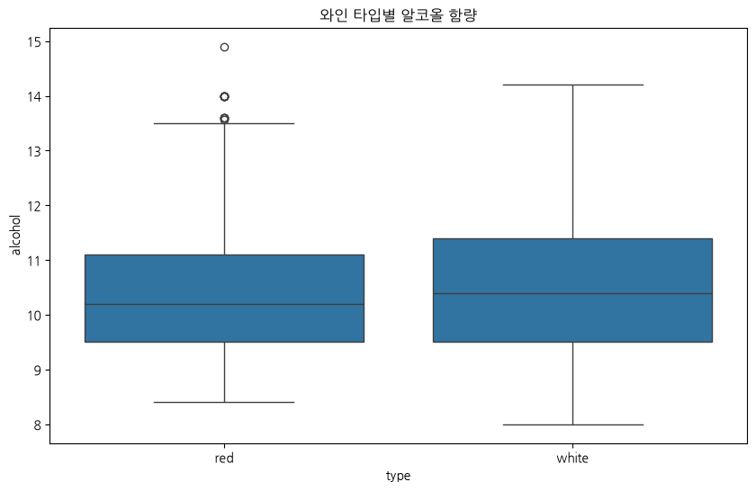

```
와인 품질별 평균 알코올 함량과 와인 수:
              mean  count
quality
3        10.215000     30
4        10.180093    216
5         9.837783   2138
6        10.587553   2836
7        11.386006   1079
8        11.678756    193
9        12.180000      5
```

```python
import pandas as pd
import seaborn as sns
import matplotlib.pyplot as plt

# 와인 데이터셋 로드 (UCI 머신러닝 리포지토리)
red_wine = pd.read_csv('https://archive.ics.uci.edu/ml/machine-learning-databases/wine-quality/winequality-red.csv', sep=';')
white_wine = pd.read_csv('https://archive.ics.uci.edu/ml/machine-learning-databases/wine-quality/winequality-white.csv', sep=';')

# 와인 타입 컬럼 추가
red_wine['type'] = 'red'
white_wine['type'] = 'white'

# 데이터셋 병합
wine = pd.concat([red_wine, white_wine])

# 실습 과제
# 1. 와인 타입별 알코올 함량 비교
plt.figure(figsize=(10, 6))
sns.boxplot(x='type', y='alcohol', data=wine)
plt.title('와인 타입별 알코올 함량')
plt.show()

# 2. 와인 품질별 통계
quality_stats = wine.groupby('quality')['alcohol'].agg(['mean', 'count'])
print("\n와인 품질별 평균 알코올 함량과 와인 수:")
print(quality_stats)
```